# Part II - Communicate Data Findings, Ford GoBike dataset

## by Gabriel Wachira

## Investigation Overview

In the investigation, I aimed at finding out the determinants or what predicted the occurrence or likelihood of a trip. I focus on the time dimension, that is trip duration and when the trips occurred. I will also focus on the riders' characteristics in the context of gender and subscription.

## Dataset Overview

The Ford GoBike dataset included information on individual rides made in a bike-sharing system covering the greater San Francisco Bay area, in February 2019. It consisted of 174,067 entries on individual trips and 20 variables describing them.

## Trip Duration Distribution

Most of the trips lasted for between 0 and 100 minutes. The majority of the trips (75%), lasted between 1 minute and 13 minutes but there is a long tail from 13 minutes onwards, up to 1409 minutes which was the longest trip.

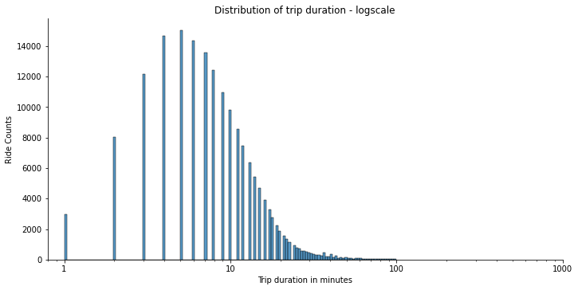

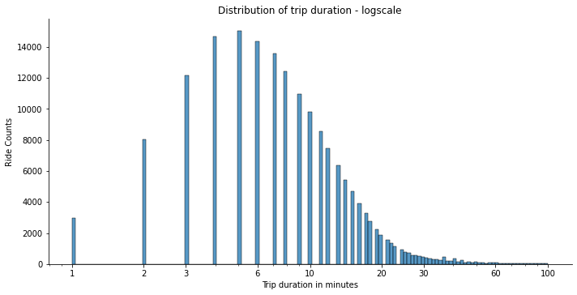

## Trip Count per Day, Hour, Weekday and Weekends

- Saturdays and Sundays were the least busy days, likely because, on weekends, fewer people were commuting to work. Thursdays were the most popular, followed by Tuesdays
- There was a bimodal peak at 8 am and 5 pm, which coincides with the time most people are commuting in the morning and in the evening. However, the bimodal peaks at 8 am and 5 pm were not observed on weekends. Instead, a gradual rise is observed from 7 am, peaking between 1 pm and 2 pm, then a gradual decline
- Trips lasted longer on weekends than on weekdays. This may suggest that people rode on weekends for leisure and on weekdays to commute, or they could just have been in less of a hurry on weekends

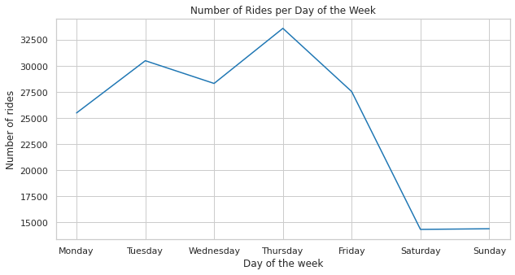

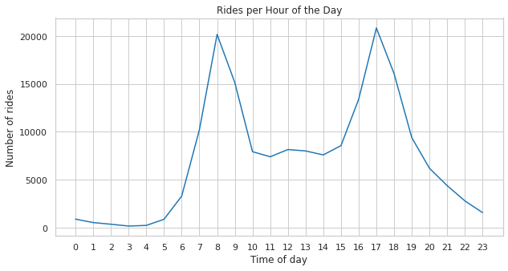

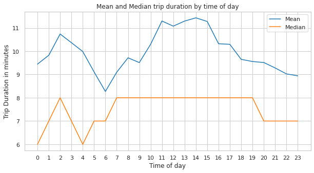

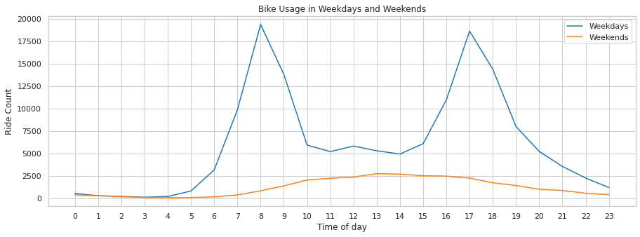

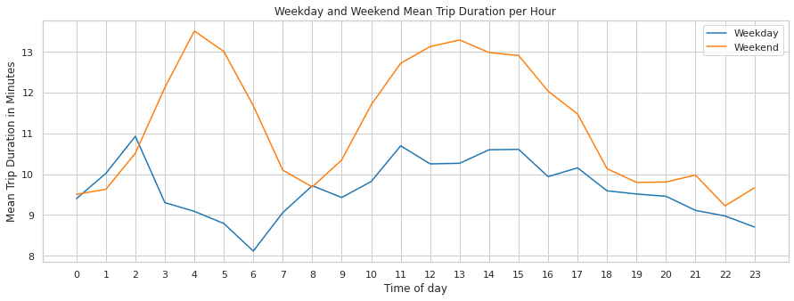

## Rider Characteristics by Gender and Subscription

A majority of the riders were subscribers (90%), with male users at more than 74%, females at about 23% and other genders at about 2%.

Males had shorter trip durations than females and other genders.

The males however rode for a cumulative 1.26 million minutes, females for 449K minutes and other genders rode for 41K minutes.

Female customers had the longest duration of trips, while male subscribers had the shortest duration of trips.

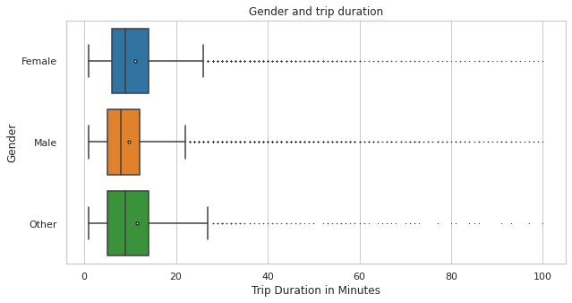